# Product Affinity Analysis (Market Basket)

Victor Gomes

2026-01-20

# Executive Summary

This analysis identifies products frequently purchased together to optimize cross-sell strategies, bundle pricing, and product recommendations.

**Objectives:** - Discover product associations and purchase patterns - Identify cross-sell and upsell opportunities - Recommend product bundles - Optimize product placement and marketing - Quantify revenue opportunities from recommendations

# Introduction to Market Basket Analysis

## What is Market Basket Analysis?

**Market Basket Analysis:** Technique to discover relationships between products by analyzing which items are frequently purchased together.

**Core Metrics:**

**Support:** How often items appear together

```
Support(A,B) = Transactions containing both A and B / Total transactions
```

**Confidence:** Given A was purchased, probability B is also purchased

```
Confidence(A→B) = Transactions with both A and B / Transactions with A
```

**Lift:** How much more likely B is purchased when A is purchased

```
Lift(A→B) = Confidence(A→B) / Support(B)
```

- Lift > 1: Positive association (A increases likelihood of B)
- Lift = 1: No association (independent)
- Lift < 1: Negative association (A decreases likelihood of B)

## Business Applications

- **Cross-sell recommendations:** “Customers who bought X also bought Y”
- **Product bundling:** Create packages of complementary items
- **Store layout:** Place associated products near each other
- **Promotional strategies:** Bundle discount offers
- **Inventory management:** Stock complementary products together

# Setup

```r
library(tidyverse)
library(lubridate)
library(here)
library(scales)
library(knitr)
library(kableExtra)
library(viridis)
library(arules)      # Association rules mining
library(arulesViz)   # Visualization of rules
library(igraph)      # Network graphs
library(ggraph)      # Graph visualization
```

# Data Loading

```r
# Load transaction data
transactions <- read_csv(here("data", "processed", "retail_customers_only.csv"))

cat("Data loaded:\n")
```

```
## Data loaded:
```

```r
cat("  Transactions:", nrow(transactions), "\n")
```

```
##   Transactions: 401571
```

```r
cat("  Unique customers:", n_distinct(transactions$CustomerID), "\n")
```

```
##   Unique customers: 4371
```

```r
cat("  Unique products:", n_distinct(transactions$StockCode), "\n")
```

```
##   Unique products: 3684
```

```r
cat("  Unique invoices:", n_distinct(transactions$InvoiceNo), "\n")
```

```
##   Unique invoices: 22187
```

# Data Preparation for Market Basket

```r
# Filter to valid sales only (exclude returns, admin items)
basket_data <- transactions %>%
  filter(
    !IsReturn,
    Quantity > 0,
    UnitPrice > 0,
    !is.na(Description),
    Description != ""
  ) %>%
  # Clean product descriptions
  mutate(
    Product = str_trim(str_to_upper(Description)),
    Product = str_replace_all(Product, "[^A-Z0-9 ]", "")  # Remove special chars
  ) %>%
  # Remove admin items
  filter(!StockCode %in% c("POST", "D", "M", "BANK CHARGES", "AMAZONFEE", "DOT", "PADS", "C2", "CRUK"))

cat("\nBasket Data Summary:\n")
```

```
##
## Basket Data Summary:
```

```r
cat("  Valid transactions:", nrow(basket_data), "\n")
```

```
##   Valid transactions: 391150
```

```r
cat("  Unique products:", n_distinct(basket_data$Product), "\n")
```

```
##   Unique products: 3850
```

```r
cat("  Unique baskets:", n_distinct(basket_data$InvoiceNo), "\n")
```

```
##   Unique baskets: 18402
```

```r
cat("  Average items per basket:", round(nrow(basket_data) / n_distinct(basket_data$InvoiceNo), 2), "\n")
```

```
##   Average items per basket: 21.26
```

# Product Popularity Analysis

Before finding associations, understand which products are most popular.

```r
# Calculate product metrics
product_stats <- basket_data %>%
  group_by(StockCode, Product) %>%
  summarize(
    Times_Purchased = n(),
    Unique_Customers = n_distinct(CustomerID),
    Unique_Baskets = n_distinct(InvoiceNo),
    Total_Quantity = sum(Quantity),
    Total_Revenue = sum(TotalAmount),
    Avg_Price = mean(UnitPrice),
    .groups = "drop"
  ) %>%
  arrange(desc(Unique_Baskets))

# Top 20 products
cat("\nTop 20 Most Popular Products:\n\n")
```

```
##
## Top 20 Most Popular Products:
```

```r
product_stats %>%
  head(20) %>%
  mutate(
    Total_Revenue = dollar(Total_Revenue, prefix = "£"),
    Avg_Price = dollar(Avg_Price, prefix = "£")
  ) %>%
  select(Product, Unique_Baskets, Unique_Customers, Total_Revenue) %>%
  kable() %>%
  kable_styling(bootstrap_options = c("striped", "hover"), font_size = 10) %>%
  scroll_box(width = "100%", height = "500px")
```

| Product | Unique_Baskets | Unique_Customers | Total_Revenue |
| --- | --- | --- | --- |
| WHITE HANGING HEART TLIGHT HOLDER | 1971 | 856 | £100,392 |
| REGENCY CAKESTAND 3 TIER | 1703 | 881 | £142,265 |
| JUMBO BAG RED RETROSPOT | 1600 | 635 | £85,041 |
| PARTY BUNTING | 1379 | 708 | £68,785 |
| ASSORTED COLOUR BIRD ORNAMENT | 1375 | 678 | £56,413 |
| LUNCH BAG RED RETROSPOT | 1288 | 532 | £27,869 |
| SET OF 3 CAKE TINS PANTRY DESIGN | 1146 | 640 | £33,298 |
| LUNCH BAG BLACK SKULL | 1052 | 458 | £17,950 |
| PACK OF 72 RETROSPOT CAKE CASES | 1029 | 635 | £16,382 |
| SPOTTY BUNTING | 1003 | 571 | £35,510 |
| LUNCH BAG SPACEBOY DESIGN | 988 | 490 | £15,820 |
| PAPER CHAIN KIT 50S CHRISTMAS | 980 | 613 | £42,584 |
| NATURAL SLATE HEART CHALKBOARD | 967 | 587 | £24,089 |
| LUNCH BAG CARS BLUE | 966 | 479 | £17,215 |
| HEART OF WICKER SMALL | 961 | 573 | £28,217 |
| LUNCH BAG PINK POLKADOT | 931 | 444 | £16,303 |
| LUNCH BAG SUKI DESIGN | 899 | 399 | £15,333 |
| JAM MAKING SET WITH JARS | 878 | 573 | £32,616 |
| ALARM CLOCK BAKELIKE RED | 877 | 388 | £25,869 |
| WOODEN PICTURE FRAME WHITE FINISH | 876 | 410 | £19,945 |

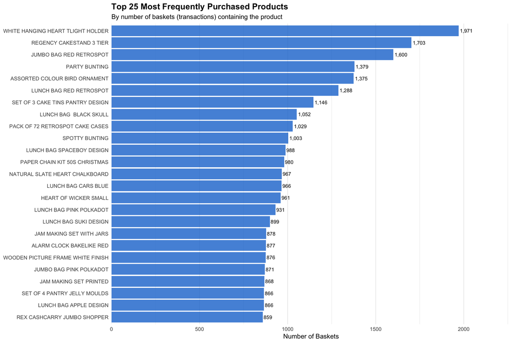

```r
# Visualize top products
product_stats %>%
  head(25) %>%
  mutate(Product = str_trunc(Product, 40)) %>%
  ggplot(aes(x = Unique_Baskets, y = reorder(Product, Unique_Baskets))) +
  geom_col(fill = "#1976D2", alpha = 0.8) +
  geom_text(aes(label = comma(Unique_Baskets)), hjust = -0.1, size = 3) +
  scale_x_continuous(expand = expansion(mult = c(0, 0.15))) +
  labs(
    title = "Top 25 Most Frequently Purchased Products",
    subtitle = "By number of baskets (transactions) containing the product",
    x = "Number of Baskets",
    y = NULL
  ) +
  theme_minimal(base_size = 11) +
  theme(
    plot.title = element_text(face = "bold", size = 14),
    panel.grid.major.y = element_blank()
  )
```

# Basket Size Distribution

```r
# Analyze basket sizes
basket_sizes <- basket_data %>%
  group_by(InvoiceNo) %>%
  summarize(
    Basket_Size = n(),
    Basket_Value = sum(TotalAmount),
    .groups = "drop"
  )

cat("\nBasket Size Statistics:\n")
```

```
##
## Basket Size Statistics:
```

```r
cat("  Average basket size:", round(mean(basket_sizes$Basket_Size), 2), "items\n")
```

```
##   Average basket size: 21.26 items
```

```r
cat("  Median basket size:", median(basket_sizes$Basket_Size), "items\n")
```

```
##   Median basket size: 15 items
```

```r
cat("  Average basket value:", dollar(mean(basket_sizes$Basket_Value), prefix = "£"), "\n")
```

```
##   Average basket value: £474.80
```

```r
cat("  Median basket value:", dollar(median(basket_sizes$Basket_Value), prefix = "£"), "\n")
```

```
##   Median basket value: £301.65
```

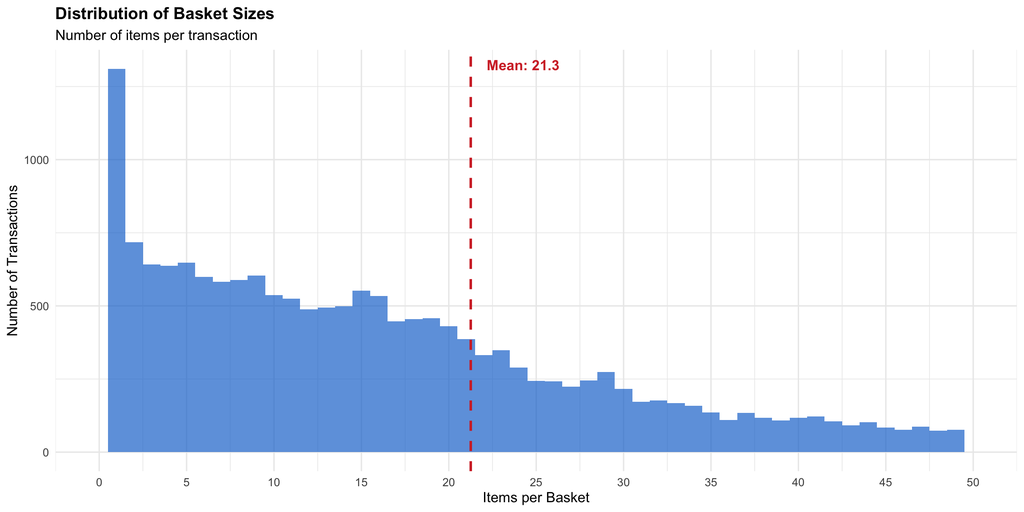

```r
# Visualize basket size distribution
ggplot(basket_sizes, aes(x = Basket_Size)) +
  geom_histogram(binwidth = 1, fill = "#1976D2", alpha = 0.7) +
  geom_vline(aes(xintercept = mean(Basket_Size)), color = "#D32F2F",
             linetype = "dashed", linewidth = 1) +
  scale_x_continuous(limits = c(0, 50), breaks = seq(0, 50, 5)) +
  annotate("text", x = mean(basket_sizes$Basket_Size) + 3, y = Inf,
           label = paste("Mean:", round(mean(basket_sizes$Basket_Size), 1)),
           vjust = 2, color = "#D32F2F", fontface = "bold") +
  labs(
    title = "Distribution of Basket Sizes",
    subtitle = "Number of items per transaction",
    x = "Items per Basket",
    y = "Number of Transactions"
  ) +
  theme_minimal(base_size = 12) +
  theme(plot.title = element_text(face = "bold", size = 14))
```

# Product Co-Occurrence Matrix

Calculate how often products appear together in baskets.

```r
# Focus on top 50 products for manageable analysis
top_products <- product_stats %>%
  head(50) %>%
  pull(Product)

# Create product pairs from same basket
product_pairs <- basket_data %>%
  filter(Product %in% top_products) %>%
  select(InvoiceNo, Product) %>%
  distinct() %>%
  inner_join(., ., by = "InvoiceNo", relationship = "many-to-many") %>%
  filter(Product.x < Product.y) %>%  # Avoid duplicates and self-pairs
  count(Product.x, Product.y, name = "Co_Occurrences") %>%
  arrange(desc(Co_Occurrences))

cat("\nProduct Association Summary:\n")
```

```
##
## Product Association Summary:
```

```r
cat("  Total unique product pairs:", nrow(product_pairs), "\n")
```

```
##   Total unique product pairs: 1225
```

```r
cat("  Top pair co-occurrences:", max(product_pairs$Co_Occurrences), "\n")
```

```
##   Top pair co-occurrences: 546
```

## Top Product Associations

```r
# Calculate association metrics
total_baskets <- n_distinct(basket_data$InvoiceNo)

product_pair_metrics <- product_pairs %>%
  left_join(product_stats %>% select(Product, P1_Baskets = Unique_Baskets),
            by = c("Product.x" = "Product")) %>%
  left_join(product_stats %>% select(Product, P2_Baskets = Unique_Baskets),
            by = c("Product.y" = "Product")) %>%
  mutate(
    # Support: % of baskets containing both
    Support = Co_Occurrences / total_baskets,

    # Confidence: Given P1, probability of P2
    Confidence_1_to_2 = Co_Occurrences / P1_Baskets,
    Confidence_2_to_1 = Co_Occurrences / P2_Baskets,

    # Lift: How much more likely together than independent
    Lift = (Co_Occurrences / total_baskets) / ((P1_Baskets / total_baskets) * (P2_Baskets / total_baskets))
  ) %>%
  filter(Lift > 1, Co_Occurrences >= 10) %>%  # Meaningful associations only
  arrange(desc(Lift))

cat("\nTop 20 Product Associations (by Lift):\n\n")
```

```
##
## Top 20 Product Associations (by Lift):
```

```r
product_pair_metrics %>%
  head(20) %>%
  mutate(
    Product.x = str_trunc(Product.x, 30),
    Product.y = str_trunc(Product.y, 30),
    Support = percent(Support, accuracy = 0.01),
    Confidence_1_to_2 = percent(Confidence_1_to_2, accuracy = 0.1),
    Lift = round(Lift, 2)
  ) %>%
  select(Product.x, Product.y, Co_Occurrences, Support, Confidence_1_to_2, Lift) %>%
  kable(col.names = c("Product A", "Product B", "Co-occur", "Support", "Confidence", "Lift")) %>%
  kable_styling(bootstrap_options = c("striped", "hover"), font_size = 10) %>%
  scroll_box(width = "100%", height = "500px")
```

| Product A | Product B | Co-occur | Support | Confidence | Lift |
| --- | --- | --- | --- | --- | --- |
| ALARM CLOCK BAKELIKE GREEN | ALARM CLOCK BAKELIKE RED | 530 | 2.88% | 67.2% | 14.09 |
| WOODEN FRAME ANTIQUE WHITE | WOODEN PICTURE FRAME WHITE … | 468 | 2.54% | 57.7% | 12.12 |
| HEART OF WICKER LARGE | HEART OF WICKER SMALL | 407 | 2.21% | 50.8% | 9.73 |
| JUMBO BAG ALPHABET | JUMBO BAG APPLES | 277 | 1.51% | 36.8% | 9.44 |
| JUMBO BAG APPLES | JUMBO BAG VINTAGE LEAF | 284 | 1.54% | 39.6% | 9.43 |
| LUNCH BAG SPACEBOY DESIGN | LUNCH BAG WOODLAND | 405 | 2.20% | 41.0% | 9.20 |
| CHOCOLATE HOT WATER BOTTLE | HOT WATER BOTTLE KEEP CALM | 246 | 1.34% | 35.1% | 8.99 |
| JUMBO BAG APPLES | LUNCH BAG APPLE DESIGN | 296 | 1.61% | 41.2% | 8.76 |
| LUNCH BAG CARS BLUE | LUNCH BAG PINK POLKADOT | 427 | 2.32% | 44.2% | 8.74 |
| LUNCH BAG BLACK SKULL | LUNCH BAG PINK POLKADOT | 464 | 2.52% | 44.1% | 8.72 |
| LUNCH BAG APPLE DESIGN | LUNCH BAG SUKI DESIGN | 360 | 1.96% | 41.6% | 8.51 |
| LUNCH BAG CARS BLUE | LUNCH BAG WOODLAND | 362 | 1.97% | 37.5% | 8.41 |
| JUMBO BAG ALPHABET | JUMBO BAG VINTAGE LEAF | 262 | 1.42% | 34.8% | 8.30 |
| LUNCH BAG CARS BLUE | LUNCH BAG SUKI DESIGN | 390 | 2.12% | 40.4% | 8.26 |
| LUNCH BAG PINK POLKADOT | LUNCH BAG RED RETROSPOT | 523 | 2.84% | 56.2% | 8.03 |
| LUNCH BAG BLACK SKULL | LUNCH BAG SUKI DESIGN | 409 | 2.22% | 38.9% | 7.96 |
| LUNCH BAG PINK POLKADOT | LUNCH BAG SUKI DESIGN | 358 | 1.95% | 38.5% | 7.87 |
| LUNCH BAG SPACEBOY DESIGN | LUNCH BAG SUKI DESIGN | 378 | 2.05% | 38.3% | 7.83 |
| LUNCH BAG APPLE DESIGN | LUNCH BAG WOODLAND | 298 | 1.62% | 34.4% | 7.72 |
| JUMBO BAG PINK POLKADOT | JUMBO STORAGE BAG SUKI | 281 | 1.53% | 32.3% | 7.67 |

**Interpretation:** - **Lift > 3:** Strong association (buy together 3x more than expected) - **Confidence > 50%:** If A purchased, >50% chance B is also purchased - **Support:** How common the combination is overall

# Association Rules Mining

Use Apriori algorithm for systematic rule discovery.

```r
# Prepare transaction data in format required by arules
basket_format <- basket_data %>%
  select(InvoiceNo, Product) %>%
  distinct() %>%
  group_by(InvoiceNo) %>%
  summarize(Products = list(Product), .groups = "drop")

# Convert to transactions format
transactions_list <- basket_format$Products
names(transactions_list) <- basket_format$InvoiceNo

# Create transactions object
trans <- as(transactions_list, "transactions")

cat("\nTransaction Data Summary:\n")
```

```
##
## Transaction Data Summary:
```

```r
cat("  Total transactions:", length(trans), "\n")
```

```
##   Total transactions: 18402
```

```r
cat("  Total unique items:", length(itemLabels(trans)), "\n")
```

```
##   Total unique items: 3850
```

```r
cat("  Density:", round(arules::size(trans) / (length(trans) * length(itemLabels(trans))) * 100, 2), "%\n")
```

[output not shown]

```r
# Mine association rules
# Parameters: min support 0.5% (appears in 0.5% of baskets), min confidence 20%
rules <- apriori(trans,
                 parameter = list(supp = 0.005, conf = 0.20, minlen = 2, maxlen = 3),
                 control = list(verbose = FALSE))

# Sort by lift
rules <- sort(rules, by = "lift", decreasing = TRUE)

cat("\nAssociation Rules Discovered:", length(rules), "\n\n")
```

```
##
## Association Rules Discovered: 4216
```

```r
# Inspect top rules
cat("Top 20 Association Rules (by Lift):\n\n")
```

```
## Top 20 Association Rules (by Lift):
```

```r
top_rules <- head(rules, 20)
rules_df <- as(top_rules, "data.frame")

rules_df %>%
  mutate(
    rules = str_replace_all(rules, "=>", " → "),
    support = percent(support, accuracy = 0.01),
    confidence = percent(confidence, accuracy = 0.1),
    lift = round(lift, 2)
  ) %>%
  kable() %>%
  kable_styling(bootstrap_options = c("striped", "hover"), font_size = 10) %>%
  scroll_box(width = "100%", height = "500px")
```

|  | rules | support | confidence | coverage | lift | count |
| --- | --- | --- | --- | --- | --- | --- |
| 1967 | {DOLLY GIRL CHILDRENS CUP,SPACEBOY CHILDRENS BOWL} → {DOLLY GIRL CHILDRENS BOWL} | 0.52% | 97.0% | 0.0053799 | 126.56 | 96 |
| 26 | {DOLLY GIRL CHILDRENS BOWL} → {DOLLY GIRL CHILDRENS CUP} | 0.64% | 83.0% | 0.0076622 | 106.04 | 117 |
| 27 | {DOLLY GIRL CHILDRENS CUP} → {DOLLY GIRL CHILDRENS BOWL} | 0.64% | 81.2% | 0.0078252 | 106.04 | 117 |
| 1966 | {DOLLY GIRL CHILDRENS BOWL,SPACEBOY CHILDRENS BOWL} → {DOLLY GIRL CHILDRENS CUP} | 0.52% | 81.4% | 0.0064123 | 103.97 | 96 |
| 60 | {SPACEBOY BEAKER} → {DOLLY GIRL BEAKER} | 0.54% | 72.5% | 0.0074992 | 100.26 | 100 |
| 61 | {DOLLY GIRL BEAKER} → {SPACEBOY BEAKER} | 0.54% | 75.2% | 0.0072275 | 100.26 | 100 |
| 40 | {PACK OF 6 SKULL PAPER CUPS} → {PACK OF 6 SKULL PAPER PLATES} | 0.62% | 78.2% | 0.0079883 | 97.93 | 115 |
| 41 | {PACK OF 6 SKULL PAPER PLATES} → {PACK OF 6 SKULL PAPER CUPS} | 0.62% | 78.2% | 0.0079883 | 97.93 | 115 |
| 22 | {PINK VINTAGE SPOT BEAKER} → {BLUE VINTAGE SPOT BEAKER} | 0.62% | 87.1% | 0.0071731 | 97.76 | 115 |
| 23 | {BLUE VINTAGE SPOT BEAKER} → {PINK VINTAGE SPOT BEAKER} | 0.62% | 70.1% | 0.0089121 | 97.76 | 115 |
| 1973 | {HERB MARKER PARSLEY,HERB MARKER THYME} → {HERB MARKER CHIVES} | 0.81% | 87.1% | 0.0092925 | 96.59 | 149 |
| 1982 | {HERB MARKER MINT,HERB MARKER PARSLEY} → {HERB MARKER CHIVES} | 0.81% | 87.1% | 0.0092925 | 96.59 | 149 |
| 1970 | {HERB MARKER MINT,HERB MARKER THYME} → {HERB MARKER CHIVES} | 0.79% | 86.9% | 0.0091294 | 96.34 | 146 |
| 1975 | {HERB MARKER BASIL,HERB MARKER CHIVES} → {HERB MARKER THYME} | 0.78% | 97.3% | 0.0079883 | 96.24 | 143 |
| 1990 | {HERB MARKER BASIL,HERB MARKER CHIVES} → {HERB MARKER PARSLEY} | 0.78% | 97.3% | 0.0079883 | 95.73 | 143 |
| 1971 | {HERB MARKER CHIVES,HERB MARKER THYME} → {HERB MARKER PARSLEY} | 0.81% | 96.8% | 0.0083687 | 95.21 | 149 |
| 1980 | {HERB MARKER CHIVES,HERB MARKER MINT} → {HERB MARKER PARSLEY} | 0.81% | 96.8% | 0.0083687 | 95.21 | 149 |
| 1993 | {HERB MARKER CHIVES,HERB MARKER ROSEMARY} → {HERB MARKER PARSLEY} | 0.81% | 96.8% | 0.0083687 | 95.21 | 149 |
| 1972 | {HERB MARKER CHIVES,HERB MARKER PARSLEY} → {HERB MARKER THYME} | 0.81% | 96.1% | 0.0084230 | 95.11 | 149 |
| 1978 | {HERB MARKER CHIVES,HERB MARKER ROSEMARY} → {HERB MARKER THYME} | 0.80% | 96.1% | 0.0083687 | 95.08 | 148 |

# Recommendation Opportunities

Identify specific cross-sell opportunities.

```r
# Focus on high-confidence rules for recommendations
strong_rules <- subset(rules, confidence > 0.30 & lift > 2)
strong_rules <- sort(strong_rules, by = "confidence", decreasing = TRUE)

cat("\nHigh-Confidence Recommendations (>30% confidence, Lift >2):\n")
```

```
##
## High-Confidence Recommendations (>30% confidence, Lift >2):
```

```r
cat("  Total strong rules:", length(strong_rules), "\n\n")
```

```
##   Total strong rules: 3248
```

```r
if(length(strong_rules) > 0) {
  recommendations_df <- as(head(strong_rules, 15), "data.frame")

  recommendations_df %>%
    mutate(
      rules = str_replace_all(rules, "=>", " → "),
      support = percent(support, accuracy = 0.01),
      confidence = percent(confidence, accuracy = 0.1),
      lift = round(lift, 2)
    ) %>%
    kable(caption = "Top 15 Product Recommendation Rules") %>%
    kable_styling(bootstrap_options = c("striped", "hover"), font_size = 10) %>%
    scroll_box(width = "100%")
}
```

Top 15 Product Recommendation Rules

|  | rules | support | confidence | coverage | lift | count |
| --- | --- | --- | --- | --- | --- | --- |
| 1975 | {HERB MARKER BASIL,HERB MARKER CHIVES} → {HERB MARKER THYME} | 0.78% | 97.3% | 0.0079883 | 96.24 | 143 |
| 1990 | {HERB MARKER BASIL,HERB MARKER CHIVES} → {HERB MARKER PARSLEY} | 0.78% | 97.3% | 0.0079883 | 95.73 | 143 |
| 1967 | {DOLLY GIRL CHILDRENS CUP,SPACEBOY CHILDRENS BOWL} → {DOLLY GIRL CHILDRENS BOWL} | 0.52% | 97.0% | 0.0053799 | 126.56 | 96 |
| 1971 | {HERB MARKER CHIVES,HERB MARKER THYME} → {HERB MARKER PARSLEY} | 0.81% | 96.8% | 0.0083687 | 95.21 | 149 |
| 1980 | {HERB MARKER CHIVES,HERB MARKER MINT} → {HERB MARKER PARSLEY} | 0.81% | 96.8% | 0.0083687 | 95.21 | 149 |
| 1993 | {HERB MARKER CHIVES,HERB MARKER ROSEMARY} → {HERB MARKER PARSLEY} | 0.81% | 96.8% | 0.0083687 | 95.21 | 149 |
| 1995 | {HERB MARKER BASIL,HERB MARKER CHIVES} → {HERB MARKER ROSEMARY} | 0.77% | 96.6% | 0.0079883 | 93.56 | 142 |
| 2066 | {HERB MARKER MINT,HERB MARKER THYME} → {HERB MARKER ROSEMARY} | 0.88% | 96.4% | 0.0091294 | 93.39 | 162 |
| 1972 | {HERB MARKER CHIVES,HERB MARKER PARSLEY} → {HERB MARKER THYME} | 0.81% | 96.1% | 0.0084230 | 95.11 | 149 |
| 1992 | {HERB MARKER CHIVES,HERB MARKER PARSLEY} → {HERB MARKER ROSEMARY} | 0.81% | 96.1% | 0.0084230 | 93.10 | 149 |
| 1981 | {HERB MARKER CHIVES,HERB MARKER PARSLEY} → {HERB MARKER MINT} | 0.81% | 96.1% | 0.0084230 | 92.62 | 149 |
| 1978 | {HERB MARKER CHIVES,HERB MARKER ROSEMARY} → {HERB MARKER THYME} | 0.80% | 96.1% | 0.0083687 | 95.08 | 148 |
| 1977 | {HERB MARKER CHIVES,HERB MARKER THYME} → {HERB MARKER ROSEMARY} | 0.80% | 96.1% | 0.0083687 | 93.08 | 148 |
| 2072 | {HERB MARKER PARSLEY,HERB MARKER THYME} → {HERB MARKER ROSEMARY} | 0.89% | 95.9% | 0.0092925 | 92.89 | 164 |
| 2075 | {HERB MARKER BASIL,HERB MARKER THYME} → {HERB MARKER ROSEMARY} | 0.88% | 95.9% | 0.0091838 | 92.84 | 162 |

# Product Network Visualization

Visualize product relationships as a network graph.

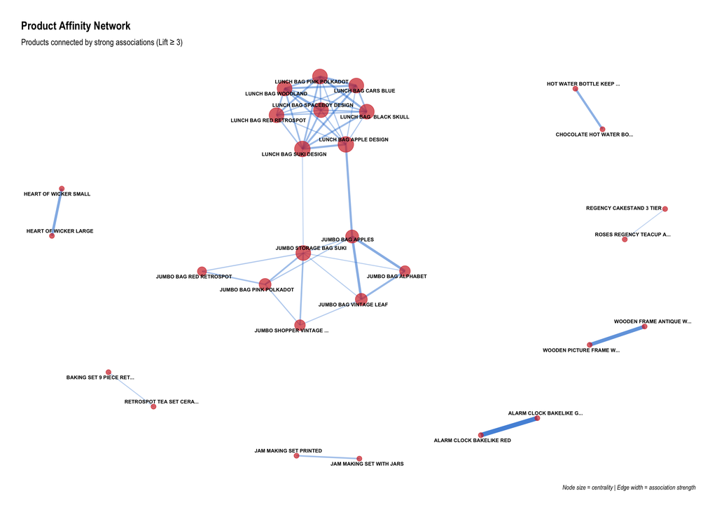

```r
# Create network from top associations
network_data <- product_pair_metrics %>%
  filter(Lift >= 3, Co_Occurrences >= 20) %>%  # Strong associations only
  head(50) %>%
  mutate(
    Product.x = str_trunc(Product.x, 25),
    Product.y = str_trunc(Product.y, 25)
  )

if(nrow(network_data) > 0) {
  # Create igraph object
  graph <- graph_from_data_frame(
    network_data %>% select(Product.x, Product.y, Lift),
    directed = FALSE
  )

  # Calculate node importance (degree)
  V(graph)$degree <- degree(graph)

  # Plot network
  ggraph(graph, layout = "fr") +
    geom_edge_link(aes(width = Lift, alpha = Lift), color = "#1976D2") +
    geom_node_point(aes(size = degree), color = "#D32F2F", alpha = 0.7) +
    geom_node_text(aes(label = name), size = 2.5, repel = TRUE,
                   max.overlaps = 20, fontface = "bold") +
    scale_edge_width(range = c(0.5, 3)) +
    scale_edge_alpha(range = c(0.3, 0.8)) +
    scale_size(range = c(3, 10)) +
    labs(
      title = "Product Affinity Network",
      subtitle = "Products connected by strong associations (Lift ≥ 3)",
      caption = "Node size = centrality | Edge width = association strength"
    ) +
    theme_graph() +
    theme(
      plot.title = element_text(face = "bold", size = 16),
      plot.subtitle = element_text(size = 12),
      legend.position = "none"
    )
} else {
  cat("Not enough strong associations for network visualization\n")
}
```

# Bundle Recommendations

Suggest product bundles based on associations.

```r
# Identify 3-item bundles with strong associations
bundle_candidates <- product_pair_metrics %>%
  filter(Lift >= 2.5, Confidence_1_to_2 >= 0.25) %>%
  arrange(desc(Lift)) %>%
  head(30)

cat("\n📦 RECOMMENDED PRODUCT BUNDLES\n")
```

```
##
## 📦 RECOMMENDED PRODUCT BUNDLES
```

```r
cat(rep("=", 70), "\n\n")
# Display top bundles
for(i in 1:min(10, nrow(bundle_candidates))) {
  p1 <- str_trunc(bundle_candidates$Product.x[i], 40)
  p2 <- str_trunc(bundle_candidates$Product.y[i], 40)
  lift <- round(bundle_candidates$Lift[i], 2)
  conf <- round(bundle_candidates$Confidence_1_to_2[i] * 100, 1)

  cat(sprintf("Bundle %d:\n", i))
  cat(sprintf("  • %s\n", p1))
  cat(sprintf("  • %s\n", p2))
  cat(sprintf("  Association: %.1f%% of %s buyers also buy second item (Lift: %.2f)\n\n",
              conf, p1, lift))
}
```

```
## Bundle 1:
##   • ALARM CLOCK BAKELIKE GREEN
##   • ALARM CLOCK BAKELIKE RED
##   Association: 67.2% of ALARM CLOCK BAKELIKE GREEN buyers also buy second item (Lift: 14.09)
##
## Bundle 2:
##   • WOODEN FRAME ANTIQUE WHITE
##   • WOODEN PICTURE FRAME WHITE FINISH
##   Association: 57.7% of WOODEN FRAME ANTIQUE WHITE buyers also buy second item (Lift: 12.12)
##
## Bundle 3:
##   • HEART OF WICKER LARGE
##   • HEART OF WICKER SMALL
##   Association: 50.8% of HEART OF WICKER LARGE buyers also buy second item (Lift: 9.73)
##
## Bundle 4:
##   • JUMBO BAG ALPHABET
##   • JUMBO BAG APPLES
##   Association: 36.8% of JUMBO BAG ALPHABET buyers also buy second item (Lift: 9.44)
##
## Bundle 5:
##   • JUMBO BAG APPLES
##   • JUMBO BAG VINTAGE LEAF
##   Association: 39.6% of JUMBO BAG APPLES buyers also buy second item (Lift: 9.43)
##
## Bundle 6:
##   • LUNCH BAG SPACEBOY DESIGN
##   • LUNCH BAG WOODLAND
##   Association: 41.0% of LUNCH BAG SPACEBOY DESIGN buyers also buy second item (Lift: 9.20)
##
## Bundle 7:
##   • CHOCOLATE HOT WATER BOTTLE
##   • HOT WATER BOTTLE KEEP CALM
##   Association: 35.1% of CHOCOLATE HOT WATER BOTTLE buyers also buy second item (Lift: 8.99)
##
## Bundle 8:
##   • JUMBO BAG APPLES
##   • LUNCH BAG APPLE DESIGN
##   Association: 41.2% of JUMBO BAG APPLES buyers also buy second item (Lift: 8.76)
##
## Bundle 9:
##   • LUNCH BAG CARS BLUE
##   • LUNCH BAG PINK POLKADOT
##   Association: 44.2% of LUNCH BAG CARS BLUE buyers also buy second item (Lift: 8.74)
##
## Bundle 10:
##   • LUNCH BAG  BLACK SKULL
##   • LUNCH BAG PINK POLKADOT
##   Association: 44.1% of LUNCH BAG  BLACK SKULL buyers also buy second item (Lift: 8.72)
```

# Revenue Opportunity Analysis

Quantify potential revenue from product recommendations.

```r
# Calculate revenue impact of recommendations
cat("\nREVENUE OPPORTUNITY FROM PRODUCT RECOMMENDATIONS\n")
```

```
##
## REVENUE OPPORTUNITY FROM PRODUCT RECOMMENDATIONS
```

```r
cat(rep("=", 70), "\n\n")
# Analyze baskets that could benefit from recommendations
single_item_baskets <- basket_sizes %>%
  filter(Basket_Size == 1) %>%
  nrow()

small_baskets <- basket_sizes %>%
  filter(Basket_Size <= 3) %>%
  nrow()

cat("Current State:\n")
```

```
## Current State:
```

```r
cat(sprintf("  • Single-item baskets: %s (%.1f%%)\n",
            comma(single_item_baskets),
            single_item_baskets / nrow(basket_sizes) * 100))
```

```
##   • Single-item baskets: 1,310 (7.1%)
```

```r
cat(sprintf("  • Small baskets (≤3 items): %s (%.1f%%)\n",
            comma(small_baskets),
            small_baskets / nrow(basket_sizes) * 100))
```

```
##   • Small baskets (≤3 items): 2,669 (14.5%)
```

```r
cat(sprintf("  • Average basket value: %s\n\n",
            dollar(mean(basket_sizes$Basket_Value), prefix = "£")))
```

```
##   • Average basket value: £474.80
```

```r
# Conservative estimates
cat("Revenue Opportunity (Conservative Estimates):\n\n")
```

```
## Revenue Opportunity (Conservative Estimates):
```

```r
# Scenario 1: Convert 10% of single-item to 2-item baskets
avg_item_value <- mean(basket_data$TotalAmount)
scenario1_revenue <- single_item_baskets * 0.10 * avg_item_value

cat("Scenario 1: Cross-sell to single-item baskets\n")
```

```
## Scenario 1: Cross-sell to single-item baskets
```

```r
cat(sprintf("  • Target: 10%% conversion rate\n"))
```

```
##   • Target: 10% conversion rate
```

```r
cat(sprintf("  • Additional items: %s\n", comma(round(single_item_baskets * 0.10))))
```

```
##   • Additional items: 131
```

```r
cat(sprintf("  • Estimated revenue: %s\n\n", dollar(scenario1_revenue, prefix = "£")))
```

```
##   • Estimated revenue: £2,926.18
```

```r
# Scenario 2: Increase average basket size by 0.5 items
scenario2_revenue <- nrow(basket_sizes) * 0.5 * avg_item_value * 0.15  # 15% take rate

cat("Scenario 2: Increase average basket size\n")
```

```
## Scenario 2: Increase average basket size
```

```r
cat(sprintf("  • Target: +0.5 items per basket average\n"))
```

```
##   • Target: +0.5 items per basket average
```

```r
cat(sprintf("  • Take rate: 15%% of customers\n"))
```

```
##   • Take rate: 15% of customers
```

```r
cat(sprintf("  • Estimated revenue: %s\n\n", dollar(scenario2_revenue, prefix = "£")))
```

```
##   • Estimated revenue: £30,828.80
```

```r
# Scenario 3: Bundle promotions
top_bundle_volume <- sum(bundle_candidates$Co_Occurrences[1:5])
scenario3_revenue <- top_bundle_volume * 0.20 * avg_item_value  # 20% incremental

cat("Scenario 3: Promote top 5 product bundles\n")
```

```
## Scenario 3: Promote top 5 product bundles
```

```r
cat(sprintf("  • Bundle discount: 10%% off\n"))
```

```
##   • Bundle discount: 10% off
```

```r
cat(sprintf("  • Expected incremental items: 20%% increase\n"))
```

```
##   • Expected incremental items: 20% increase
```

```r
cat(sprintf("  • Estimated revenue: %s\n\n", dollar(scenario3_revenue, prefix = "£")))
```

```
##   • Estimated revenue: £8,783.02
```

```r
total_opportunity <- scenario1_revenue + scenario2_revenue + scenario3_revenue
cat(sprintf("💰 TOTAL ANNUAL OPPORTUNITY: %s\n\n",
            dollar(total_opportunity, prefix = "£")))
```

```
## 💰 TOTAL ANNUAL OPPORTUNITY: £42,538.00
```

```r
cat(rep("=", 70), "\n\n")
```

# Strategic Recommendations

```r
cat("\nACTIONABLE RECOMMENDATIONS\n")
```

```
##
## ACTIONABLE RECOMMENDATIONS
```

```r
cat(rep("=", 70), "\n\n")
cat("🎯 PRIORITY 1: Implement Recommendation Engine\n")
```

```
## 🎯 PRIORITY 1: Implement Recommendation Engine
```

```r
cat("   Actions:\n")
```

```
##    Actions:
```

```r
cat("   • Add \"Customers also bought\" on product pages\n")
```

```
##    • Add "Customers also bought" on product pages
```

```r
cat("   • Show top 3-5 related products based on association rules\n")
```

```
##    • Show top 3-5 related products based on association rules
```

```r
cat("   • Display during checkout process\n")
```

```
##    • Display during checkout process
```

```r
cat("   • A/B test placement and messaging\n")
```

```
##    • A/B test placement and messaging
```

```r
cat(sprintf("   • Expected impact: %s annual revenue\n\n",
            dollar(scenario1_revenue + scenario2_revenue, prefix = "£")))
```

```
##    • Expected impact: £33,754.98 annual revenue
```

```r
cat("🎯 PRIORITY 2: Create Product Bundles\n")
```

```
## 🎯 PRIORITY 2: Create Product Bundles
```

```r
cat("   Actions:\n")
```

```
##    Actions:
```

```r
cat("   • Launch top 10 product bundles with 10% discount\n")
```

```
##    • Launch top 10 product bundles with 10% discount
```

```r
cat("   • Prominent placement on homepage and category pages\n")
```

```
##    • Prominent placement on homepage and category pages
```

```r
cat("   • Email campaign to existing customers\n")
```

```
##    • Email campaign to existing customers
```

```r
cat("   • Track bundle performance vs individual sales\n")
```

```
##    • Track bundle performance vs individual sales
```

```r
cat(sprintf("   • Expected impact: %s annual revenue\n\n",
            dollar(scenario3_revenue, prefix = "£")))
```

```
##    • Expected impact: £8,783.02 annual revenue
```

```r
cat("🎯 PRIORITY 3: Optimize Product Placement\n")
```

```
## 🎯 PRIORITY 3: Optimize Product Placement
```

```r
cat("   Actions:\n")
```

```
##    Actions:
```

```r
cat("   • Group associated products in same categories\n")
```

```
##    • Group associated products in same categories
```

```r
cat("   • Adjacent placement in catalogs/emails\n")
```

```
##    • Adjacent placement in catalogs/emails
```

```r
cat("   • \"Complete the set\" messaging\n")
```

```
##    • "Complete the set" messaging
```

```r
cat("   • Visual merchandising based on associations\n\n")
```

```
##    • Visual merchandising based on associations
```

```r
cat("🎯 PRIORITY 4: Personalized Email Campaigns\n")
```

```
## 🎯 PRIORITY 4: Personalized Email Campaigns
```

```r
cat("   Actions:\n")
```

```
##    Actions:
```

```r
cat("   • Send targeted cross-sell emails based on past purchases\n")
```

```
##    • Send targeted cross-sell emails based on past purchases
```

```r
cat("   • \"You might also like\" recommendations\n")
```

```
##    • "You might also like" recommendations
```

```r
cat("   • Time recommendations based on purchase cycles\n")
```

```
##    • Time recommendations based on purchase cycles
```

```r
cat("   • Segment by customer value (CLV tiers)\n\n")
```

```
##    • Segment by customer value (CLV tiers)
```

```r
cat("🎯 PRIORITY 5: Monitor and Optimize\n")
```

```
## 🎯 PRIORITY 5: Monitor and Optimize
```

```r
cat("   Actions:\n")
```

```
##    Actions:
```

```r
cat("   • Track recommendation click-through rates\n")
```

```
##    • Track recommendation click-through rates
```

```r
cat("   • Measure conversion rates by recommendation type\n")
```

```
##    • Measure conversion rates by recommendation type
```

```r
cat("   • Update association rules monthly\n")
```

```
##    • Update association rules monthly
```

```r
cat("   • A/B test different recommendation strategies\n\n")
```

```
##    • A/B test different recommendation strategies
```

```r
cat(rep("=", 70), "\n\n")
```

# Export Recommendations

```r
# Export recommendation rules for implementation
if(length(strong_rules) > 0) {
  recommendations_export <- as(strong_rules, "data.frame") %>%
    separate(rules, into = c("Antecedent", "Consequent"), sep = " => ") %>%
    mutate(
      Antecedent = str_remove_all(Antecedent, "[{}]"),
      Consequent = str_remove_all(Consequent, "[{}]")
    ) %>%
    arrange(desc(confidence))

  export_path <- here("data", "processed", "product_recommendations.csv")
  write_csv(recommendations_export, export_path)

  cat("✓ Product recommendations exported to:", export_path, "\n")
  cat("  Rules exported:", nrow(recommendations_export), "\n\n")

  cat("Ready for:\n")
  cat("  • E-commerce platform integration\n")
  cat("  • Recommendation engine\n")
  cat("  • Marketing campaign targeting\n")
  cat("  • Merchandising decisions\n")
}
```

```
## ✓ Product recommendations exported to: /Users/joaovictorgomes/Documents/ecommerce-customer-analytics/data/processed/product_recommendations.csv
##   Rules exported: 3248
##
## Ready for:
##   • E-commerce platform integration
##   • Recommendation engine
##   • Marketing campaign targeting
##   • Merchandising decisions
```

# Summary & Key Takeaways

```r
cat("\n")
```

```r
cat(rep("=", 70), "\n")
cat("            PRODUCT AFFINITY ANALYSIS COMPLETE\n")
```

```
##             PRODUCT AFFINITY ANALYSIS COMPLETE
```

```r
cat(rep("=", 70), "\n\n")
cat("✅ ACHIEVEMENTS:\n\n")
```

```
## ✅ ACHIEVEMENTS:
```

```r
cat("  1. Analyzed", n_distinct(basket_data$InvoiceNo), "baskets\n")
```

```
##   1. Analyzed 18402 baskets
```

```r
cat("  2. Discovered", length(rules), "association rules\n")
```

```
##   2. Discovered 4216 association rules
```

```r
cat("  3. Identified", length(strong_rules), "high-confidence recommendations\n")
```

```
##   3. Identified 3248 high-confidence recommendations
```

```r
cat("  4. Created product network showing",
    nrow(network_data), "strong associations\n")
```

```
##   4. Created product network showing 50 strong associations
```

```r
cat("  5. Quantified revenue opportunity:",
    dollar(total_opportunity, prefix = "£"), "\n\n")
```

```
##   5. Quantified revenue opportunity: £42,538.00
```

```r
cat("🎯 KEY INSIGHTS:\n\n")
```

```
## 🎯 KEY INSIGHTS:
```

```r
cat(sprintf("  • Average basket size: %.1f items\n", mean(basket_sizes$Basket_Size)))
```

```
##   • Average basket size: 21.3 items
```

```r
cat(sprintf("  • Single-item baskets: %.1f%% (cross-sell opportunity)\n",
            single_item_baskets / nrow(basket_sizes) * 100))
```

```
##   • Single-item baskets: 7.1% (cross-sell opportunity)
```

```r
cat(sprintf("  • Top association lift: %.1fx\n", max(product_pair_metrics$Lift)))
```

```
##   • Top association lift: 14.1x
```

```r
cat(sprintf("  • Revenue opportunity: %s annually\n",
            dollar(total_opportunity, prefix = "£")))
```

```
##   • Revenue opportunity: £42,538.00 annually
```

```r
cat("\n💡 NEXT STEPS:\n\n")
```

```
##
## 💡 NEXT STEPS:
```

```r
cat("  1. Implement recommendation engine on website\n")
```

```
##   1. Implement recommendation engine on website
```

```r
cat("  2. Launch top 10 product bundles\n")
```

```
##   2. Launch top 10 product bundles
```

```r
cat("  3. A/B test recommendation placements\n")
```

```
##   3. A/B test recommendation placements
```

```r
cat("  4. Set up monthly rule updates\n")
```

```
##   4. Set up monthly rule updates
```

```r
cat("  5. Track recommendation performance metrics\n\n")
```

```
##   5. Track recommendation performance metrics
```

```r
cat(rep("=", 70), "\n\n")
```

**✅ Product Affinity Analysis Complete!**

*This analysis enables data-driven cross-sell strategies and product bundling.*